# Rstudio Table Contest

NEW!

[figure not shown]

**The Beatles Anthology** (1995)

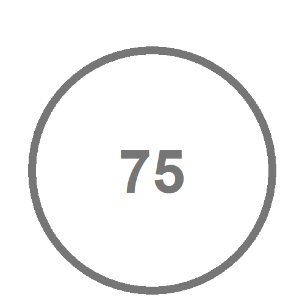

Documentary  
Music

9.0

7,232

1 season  
8 episodes

S01E04  
S01E05  
S01E06  
S01E07  
S01E08

[figure not shown]

26

↑+1

[figure not shown]

**Batman: The Animated Series** (1992)

Action  
Adventure  
Animation

9.0

84,901

4 seasons  
85 episodes

S01E35

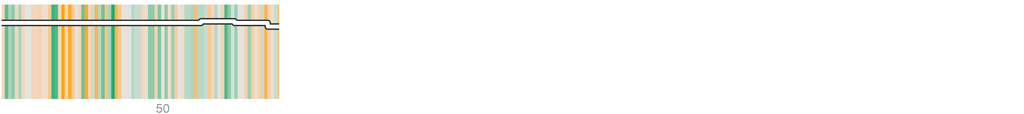

27

↑+6

[figure not shown]

**Frozen Planet** (2011)

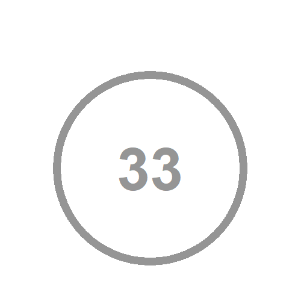

Documentary

9.0

26,110

1 season  
10 episodes

S01E01

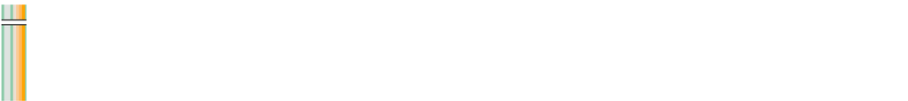

28

↓-5

[figure not shown]

**Firefly** (2002)

Adventure  
Drama  
Sci-Fi

9.0

240,267

1 season  
14 episodes

S01E05

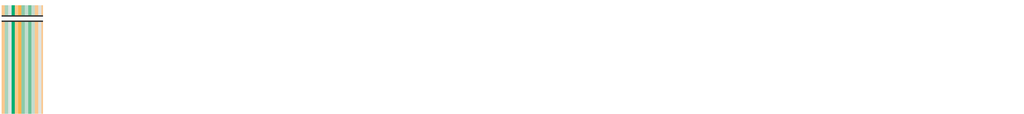

29

↓-8

[figure not shown]

**Dekalog** (1989)

Drama

8.9

21,302

1 season  
10 episodes

S01E06

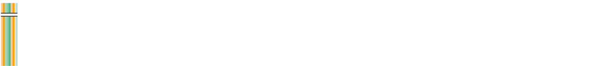

30

↓-5

[figure not shown]

**True Detective** (2014)

Crime  
Drama  
Mystery

8.9

487,050

3 seasons  
24 episodes

S01E04

[figure not shown]

31

↓-2

[figure not shown]

**Death Note** (2006)

Animation  
Crime  
Drama

8.9

221,464

1 season  
37 episodes

S01E25

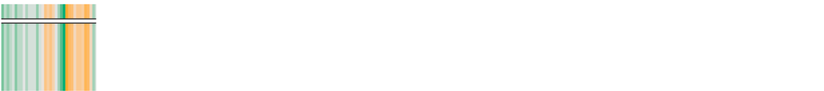

32

↓-10

[figure not shown]

**The Civil War** (1990)

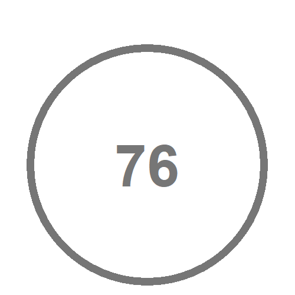

Documentary  
History  
War

8.9

13,246

1 season  
9 episodes

S01E05  
S01E08  
S01E09

[figure not shown]

33

↑+8

[figure not shown]

**Der Krieg** (2009)  
(Apocalypse: La 2ème guerre mondiale)

Documentary  
History  
War

8.9

9,432

1 season  
6 episodes

S01E06

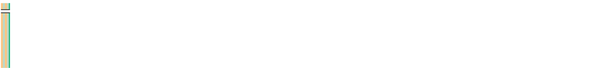

34

↓-8

[figure not shown]

**Fargo** (2014)

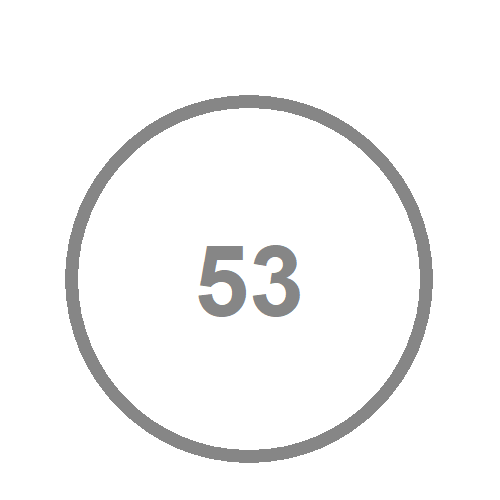

Crime  
Drama  
Thriller

8.9

313,323

4 seasons  
35 episodes

S02E08  
S02E09

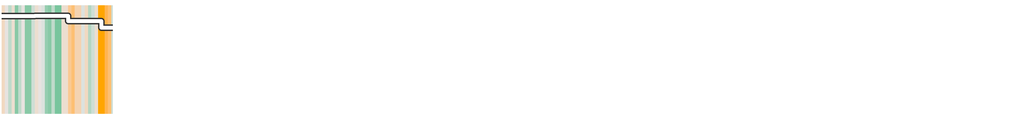

35

↓-4

[figure not shown]

**Cowboy Bebop** (1998)  
(Kaubôi bibappu)

Action  
Adventure  
Animation

8.9

86,169

1 season  
26 episodes

S01E26

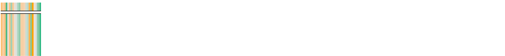

36

↓-1

[figure not shown]

**Africa** (2013)

Documentary

8.9

13,742

1 season  
6 episodes

S01E01

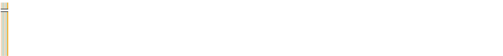

37

NEW!

[figure not shown]

**When They See Us** (2019)

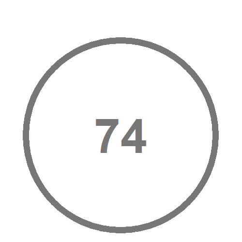

Biography  
Crime  
Drama

8.9

84,154

1 season  
4 episodes

S01E04

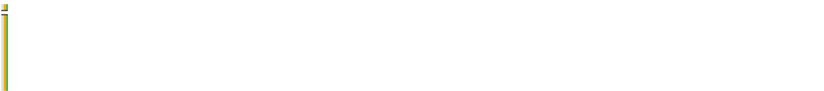

38

↓-10

[figure not shown]

**Last Week Tonight with John Oliver** (2014)

Comedy  
News  
Talk-Show

8.9

77,095

7 seasons  
204 episodes

S06E29

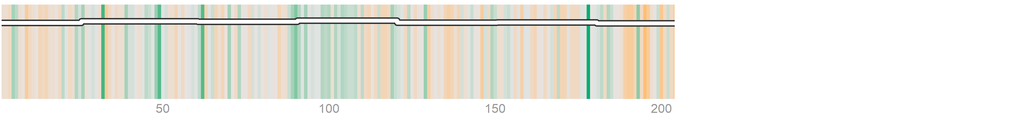

39

↑+81

[figure not shown]

**Hunter x Hunter** (2011)

Action  
Adventure  
Animation

8.9

49,404

1 season  
148 episodes

S01E126  
S01E131  
S01E135

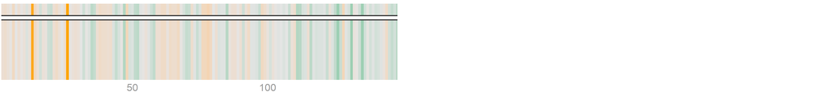

40

↑+13

[figure not shown]

**TVF Pitchers** (2015)

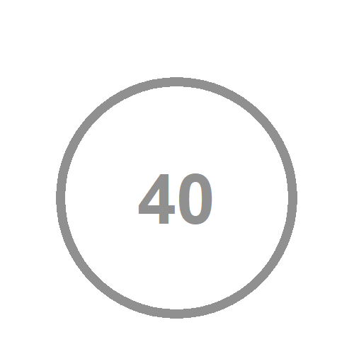

Comedy  
Drama

8.8

50,569

1 season  
5 episodes

S01E05

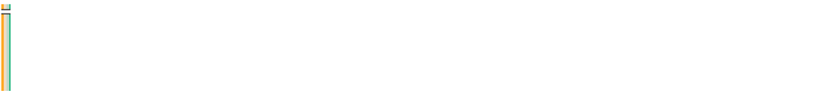

41

↓-1

[figure not shown]

**Only Fools & Horses** (1981)  
(Only Fools & Horses....)

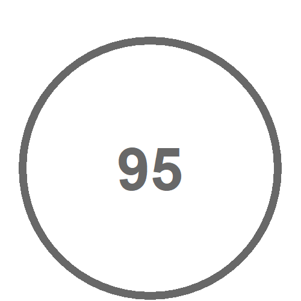

Comedy

8.8

45,216

9 seasons  
64 episodes

S06E07

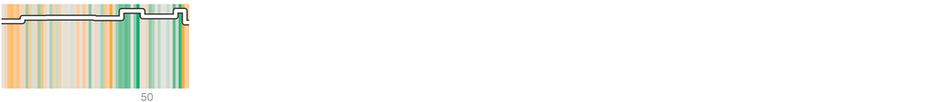

42

↑+9

[figure not shown]

**The Office** (2005)

Comedy

8.8

385,277

9 seasons  
188 episodes

S07E21  
S09E23

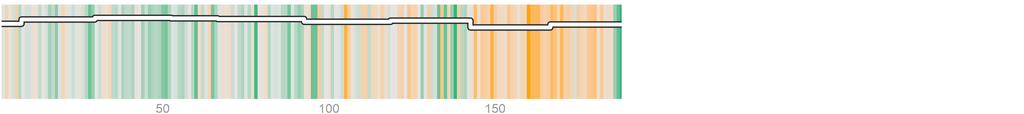

43

NEW!

[figure not shown]

**SCAM 1992: The Harshad Mehta Story** (2020)

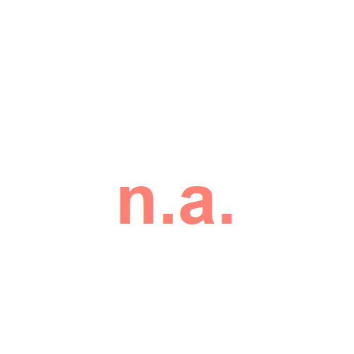

Biography  
Crime  
Drama

8.8

10,645

1 season  
10 episodes

S01E03  
S01E04  
S01E09  
S01E10

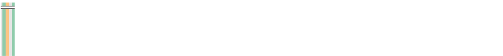

44

↓-5

[figure not shown]

**Friends** (1994)

Comedy  
Romance

8.8

793,021

10 seasons  
235 episodes

S05E14  
S10E17

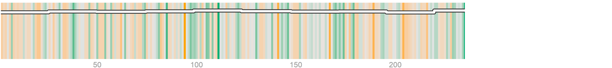

45

↑+1

[figure not shown]

**Gravity Falls** (2012)

Adventure  
Animation  
Comedy

8.8

68,953

2 seasons  
40 episodes

S02E11  
S02E20

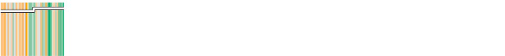

46

↓-8

[figure not shown]

**Das Boot** (1985)

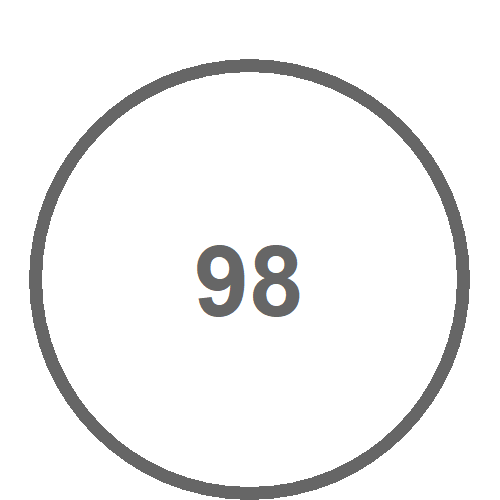

Drama  
Thriller  
War

8.8

25,700

1 season  
3 episodes

S01E03

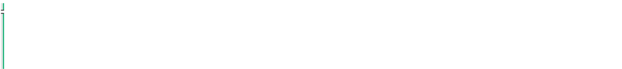

47

↓-5

[figure not shown]

**Seinfeld** (1989)

Comedy

8.8

248,675

9 seasons  
172 episodes

S04E11  
S05E21

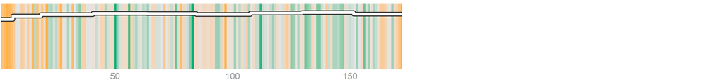

48

↓-12

[figure not shown]

**Monty Python’s Flying Circus** (1969)

Comedy

8.8

66,066

4 seasons  
45 episodes

S02E02

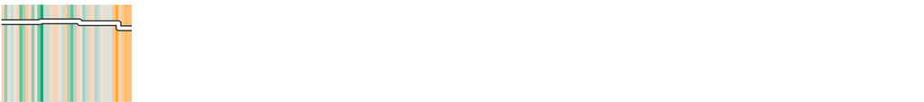

49

↓-12

[figure not shown]

**Pride & Prejudice** (1995)

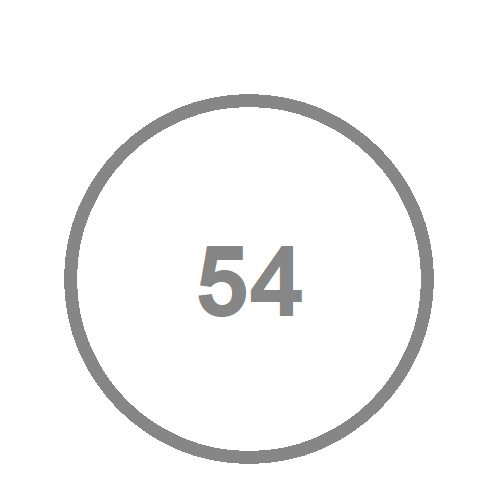

Drama  
Romance

8.8

74,154

1 season  
6 episodes

S01E06

[figure not shown]

50

NEW!

[figure not shown]

**Ramayan** (1987)

Adventure  
Drama  
Family

8.8

12,250

1 season  
78 episodes

S01E71

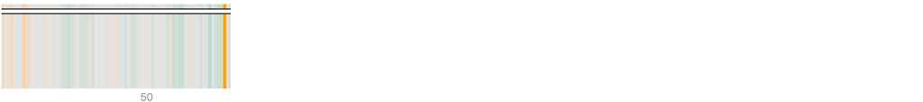

51

↓-19

[figure not shown]

**Black Mirror** (2011)

Drama  
Sci-Fi  
Thriller

8.8

422,999

5 seasons  
22 episodes

S02E04

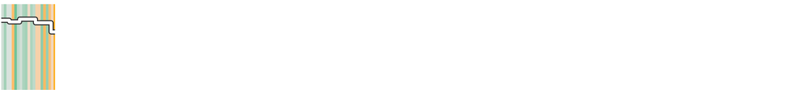

52

NEW!

[figure not shown]

**How the Universe Works** (2010)

Documentary

8.8

5,557

8 seasons  
71 episodes

S07E10

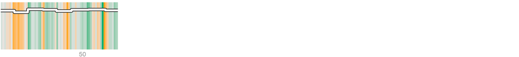

53

↑+15

[figure not shown]

**Nathan for You** (2013)

Comedy  
Documentary

8.8

17,963

4 seasons  
32 episodes

S04E08

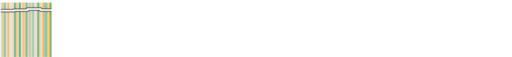

54

↓-7

[figure not shown]

**Twin Peaks** (1990)

Crime  
Drama  
Mystery

8.8

170,564

2 seasons  
30 episodes

S02E07

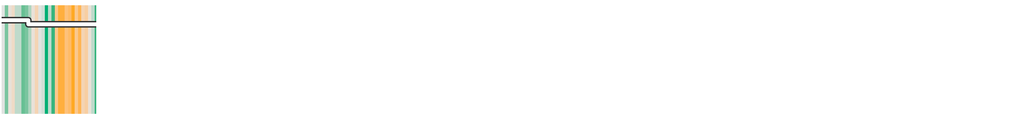

55

↓-7

[figure not shown]

**Over the Garden Wall** (2014)

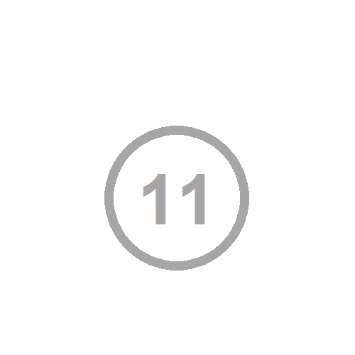

Animation  
Adventure  
Drama

8.8

38,020

1 season  
10 episodes

S01E10

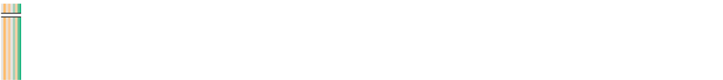

56

↓-7

[figure not shown]

**Narcos** (2015)

Biography  
Crime  
Drama

8.7

343,539

3 seasons  
30 episodes

S02E10

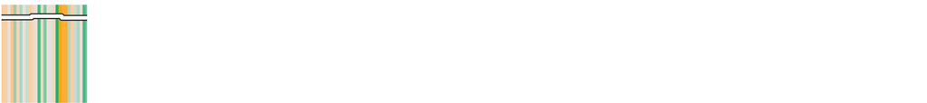

57

↑+9

[figure not shown]

**Attack on Titan** (2013)

Animation  
Action  
Adventure

8.7

149,487

3 seasons  
59 episodes

S03E16  
S03E17  
S03E18  
S03E20

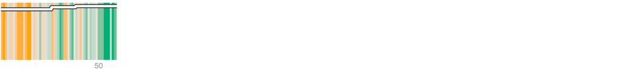

58

↓-24

[figure not shown]

**One Punch Man** (2015)

Animation  
Action  
Comedy

8.7

108,369

2 seasons  
24 episodes

S01E12

[figure not shown]

59

↑+2

[figure not shown]

**Blackadder Goes Forth** (1989)

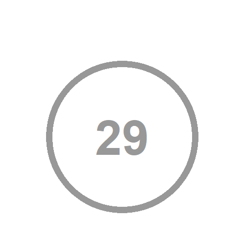

Comedy  
War

8.7

47,573

1 season  
6 episodes

S01E06

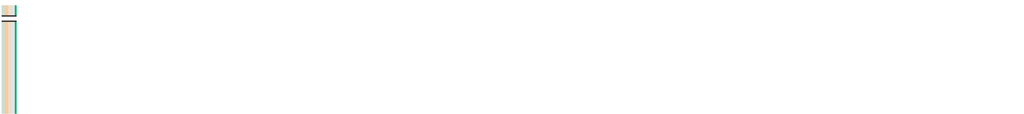

60

↓-3

[figure not shown]

**Peaky Blinders** (2013)

Crime  
Drama

8.7

315,450

5 seasons  
30 episodes

S02E06  
S03E06

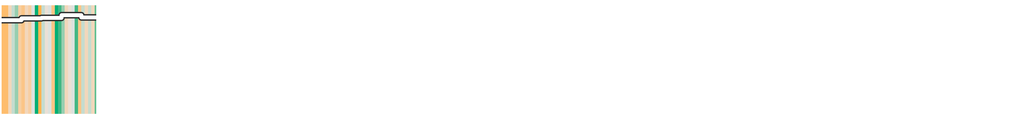

61